# Sentiment Analysis Project Todoist App Reviews on Google Playstore

*Author: Nanda Yuli Akhirdianto*

**Background:** In today's digital era, mobile applications are an important part of the daily lives of smartphone users. One of the more popular apps used to manage tasks and lists is Todoist. This application allows users to manage schedules, create to-do lists, set reminders, and much more. To understand the user's view of this application, sentiment analysis of user reviews on Google Playstore is important.

**Objective:** The aim of this project is to carry out a sentiment analysis of the Todoist app reviews received from users on the Google Playstore. Through this analysis, we can understand whether the views of users in general tend to be positive, negative, or neutral towards this application. In addition, we can identify specific aspects that users might highlight, both positive and negative, which can provide app developers with valuable insights in improving the user experience.

By conducting a sentiment analysis of these Todoist app reviews, we can gain valuable insight into how users view the app as a whole. This information can assist application developers in identifying application strengths and weaknesses, as well as provide a solid basis for decision-making in improving the user experience.

#### **Setup**

```python
import pandas as pd
import numpy as np
import matplotlib.pyplot as plt
import seaborn as sns

data = pd.read_csv('notebook/sentiment_app_review_analysis/reviews_app.csv')
```

```python
df = data[data['appId'] == 'com.todoist']
df.sample(10)
```

|  | reviewId | userName | userImage | content | score | thumbsUpCount | reviewCreatedVersion | at | replyContent | repliedAt | appVersion | sortOrder | appId |
| --- | --- | --- | --- | --- | --- | --- | --- | --- | --- | --- | --- | --- | --- |
| 649 | fbfca580-80cf-4d5f-ab29-377087302ee7 | Evgeny Apenkin | https://play-lh.googleusercontent.com/a-/AD_cM... | I liked the markdown support. Links editing in... | 3 | 0 | v10726 | 2023-02-03 21:04:12 | Hi Evgeny, we still support Markdown, typing M... | 2023-02-04 00:40:47 | v10726 | newest | com.todoist |
| 453 | 265c0bbd-0123-4431-b40d-d3acea7577b6 | A Google user | https://play-lh.googleusercontent.com/EGemoI2N... | I like the way this app is so intuitive to use... | 3 | 2 | 14.1.0 | 2019-03-24 15:54:48 | Ruth, the circles won't delete the task, these... | 2019-03-26 19:51:54 | 14.1.0 | most_relevant | com.todoist |
| 360 | 3409bb1b-f6b1-4999-9e5e-579f69b0dbd7 | Cory | https://play-lh.googleusercontent.com/a-/AD_cM... | meh | 2 | 0 | v10622 | 2022-12-13 00:09:06 | Hello! Thanks for your review! We would love t... | 2022-12-14 13:48:20 | v10622 | newest | com.todoist |
| 379 | 7cc514c7-8d22-4e79-ad27-4b5ed47f4f09 | DL Tech | https://play-lh.googleusercontent.com/a-/AD_cM... | Really bad for image attachment for task | 2 | 0 | NaN | 2022-11-02 02:08:05 | Hello! Thanks for your feedback. We would like... | 2022-11-02 21:08:25 | NaN | newest | com.todoist |
| 279 | 3dd1cb19-3a7f-40e1-bd8c-10e549a95ff6 | A Google user | https://play-lh.googleusercontent.com/EGemoI2N... | The new update is awful. I have to do so many ... | 2 | 3 | 15.0.2 | 2019-11-02 20:30:28 | Alexander, sorry to hear that, we'll bring bac... | 2019-11-04 20:00:45 | 15.0.2 | most_relevant | com.todoist |
| 369 | b4de26a2-de91-431a-9830-c1df06415530 | Thomas Sharratt | https://play-lh.googleusercontent.com/a-/AD_cM... | Why has the daily notification stopped outlini... | 2 | 0 | v10610 | 2022-11-28 16:07:42 | Hi Thomas! Are you referring to the morning ov... | 2022-11-29 11:22:23 | v10610 | newest | com.todoist |
| 876 | 6d294a9c-1f34-4ae1-ba5c-7c5bc1d2ce16 | Tom Speleman | https://play-lh.googleusercontent.com/a/AAcHTt... | Does what it needs to do. Very good integratio... | 4 | 19 | 15.7.3 | 2020-07-04 15:31:52 | Hello, you can set a custom event duration fro... | 2020-07-07 01:54:05 | 15.7.3 | most_relevant | com.todoist |
| 562 | 144eb812-f156-463c-97d7-5ad6d148ddb8 | Gareth | https://play-lh.googleusercontent.com/a/AAcHTt... | Good functionally but slow app. The widget alm... | 3 | 3 | v9498 | 2022-04-14 19:57:42 | Hello, would you be able to submit a ticket at... | 2022-04-18 18:30:44 | v9498 | most_relevant | com.todoist |
| 1012 | 3219a89f-8601-46bb-9c3b-b2151e78329a | A Google user | https://play-lh.googleusercontent.com/EGemoI2N... | Simply brilliant. Everything you could want. T... | 5 | 5 | 14.3.0 | 2019-06-22 17:01:13 | NaN | NaN | 14.3.0 | most_relevant | com.todoist |
| 746 | b2156818-3414-4f6b-8a6a-8f09d53a3f57 | Ahmed | https://play-lh.googleusercontent.com/a/AAcHTt... | As a student, not having at least 10 projects ... | 3 | 0 | v9304 | 2022-03-11 13:50:47 | NaN | NaN | v9304 | newest | com.todoist |

#### **Data Validation and Cleaning Process**

```python
len(df)
```

```
1200
```

```python
# Remove some columns that aren't used in further process
df = df.drop('reviewId', axis=1)
df = df.drop('userImage', axis=1)
df = df.drop('thumbsUpCount', axis=1)
df = df.drop('reviewCreatedVersion', axis=1)
df = df.drop('replyContent', axis=1)
df = df.drop('repliedAt', axis=1)
df = df.drop('sortOrder', axis=1)
df = df.drop('appId', axis=1)

print(df.columns)
```

```
Index(['userName', 'content', 'score', 'at', 'appVersion'], dtype='object')
```

```python
# Geting to know about data description
print(df.shape)
print(df.info())

# Getting to know how much rate that users used to give
print(df.loc[:, 'score'].mean())
```

```
(1200, 5)
<class 'pandas.core.frame.DataFrame'>
Int64Index: 1200 entries, 0 to 1199
Data columns (total 5 columns):
 #   Column      Non-Null Count  Dtype
---  ------      --------------  -----
 0   userName    1200 non-null   object
 1   content     1200 non-null   object
 2   score       1200 non-null   int64
 3   at          1200 non-null   object
 4   appVersion  1024 non-null   object
dtypes: int64(1), object(4)
memory usage: 56.2+ KB
None
3.0
```

```python
# Change some columns name for better understanding
df = df.rename(columns={
    'userName': 'user',
    'content': 'reviews',
    'score': 'rating',
    'at': 'date',
    'appVersion': 'app_ver'
})

print(df.columns)
```

```
Index(['user', 'reviews', 'rating', 'date', 'app_ver'], dtype='object')
```

```python
# format 'date' data type into datetime format
df['date'] = pd.to_datetime(df['date'], format='%Y-%m-%d')
print(df.info())
```

```
<class 'pandas.core.frame.DataFrame'>
Int64Index: 1200 entries, 0 to 1199
Data columns (total 5 columns):
 #   Column   Non-Null Count  Dtype
---  ------   --------------  -----
 0   user     1200 non-null   object
 1   reviews  1200 non-null   object
 2   rating   1200 non-null   int64
 3   date     1200 non-null   datetime64[ns]
 4   app_ver  1024 non-null   object
dtypes: datetime64[ns](1), int64(1), object(3)
memory usage: 56.2+ KB
None
```

```python
# Identify if any missing values and duplicate data
print(df.isnull().sum())
print(df.duplicated())
```

```
user         0
reviews      0
rating       0
date         0
app_ver    176
dtype: int64
0       False
1       False
2       False
3       False
4       False
        ...
1195    False
1196    False
1197    False
1198    False
1199    False
Length: 1200, dtype: bool
```

```python
# There are 176 rows that have missing value, since those missing value are on string we put 'unknown version' into it.
df['app_ver'].fillna('unknown version', inplace=True)

print(df.head())
```

```
              user                                            reviews  rating  \
0  Christina James  SEIZURE RISK!!!! I have had this app for years...       1
1     Sean Fellows  It's been three months and the app still stops...       1
2    A Google user  One of the main sticking points for me is how ...       1
3   Amber Knowlton  What is the point of a "To Do" list without re...       1
4      Anna Fowler  To start, notifications shouldn't be a premium...       1

                 date          app_ver
0 2023-06-08 21:25:14           v10902
1 2023-05-16 08:06:10           v10874
2 2019-12-23 13:56:54  unknown version
3 2021-03-18 22:31:37  unknown version
4 2021-02-27 14:49:45            v7790
```

```python
doist = df
doist.head()
```

|  | user | reviews | rating | date | app_ver |
| --- | --- | --- | --- | --- | --- |
| 0 | Christina James | SEIZURE RISK!!!! I have had this app for years... | 1 | 2023-06-08 21:25:14 | v10902 |
| 1 | Sean Fellows | It's been three months and the app still stops... | 1 | 2023-05-16 08:06:10 | v10874 |
| 2 | A Google user | One of the main sticking points for me is how ... | 1 | 2019-12-23 13:56:54 | unknown version |
| 3 | Amber Knowlton | What is the point of a "To Do" list without re... | 1 | 2021-03-18 22:31:37 | unknown version |
| 4 | Anna Fowler | To start, notifications shouldn't be a premium... | 1 | 2021-02-27 14:49:45 | v7790 |

#### **Analyze Process**

We're conducting data exploration to interpret and gaining insight from this dataset by answering some questions.

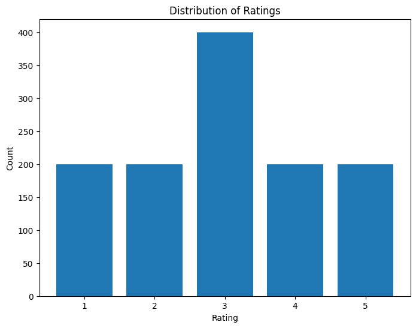

```python
# Displays the distribution of scores (ratings)
rating_counts = doist['rating'].value_counts().sort_index()

# Make a bar plot for the distribution of scores (ratings)
plt.figure(figsize=(8, 6))
plt.bar(rating_counts.index, rating_counts.values)
plt.xlabel('Rating')
plt.ylabel('Count')
plt.title('Distribution of Ratings')
plt.show()
```

That chart proves that the average of rating this app has earned is 3.0. Next, we want to know the distribution of the number of reviews by user, as well as evaluate the distribution of ratings from each user to the application.

```
User with the most number of reviews:
A Google user
```

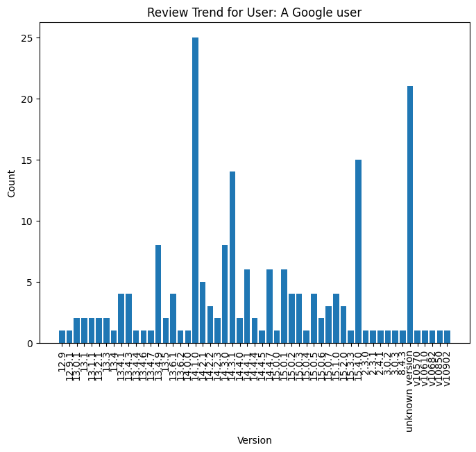

```python
# Identify the user with the most number of reviews (user)
top_reviewers = doist['user'].value_counts().head(5)
most_reviews_user = top_reviewers.index[0]

print("User with the most number of reviews:")
print(most_reviews_user)

# Analyze trends or patterns in the most user reviews
user_reviews = doist[doist['user'] == most_reviews_user]
review_counts = user_reviews['app_ver'].value_counts().sort_index()

# Generates a bar plot for the most trending user reviews
plt.figure(figsize=(8, 6))
plt.bar(review_counts.index, review_counts.values)
plt.xlabel('Version')
plt.ylabel('Count')
plt.title('Review Trend for User: ' + most_reviews_user)
plt.xticks(rotation=90)
plt.show()
```

Next, we want to see the relationship between rating and app version.

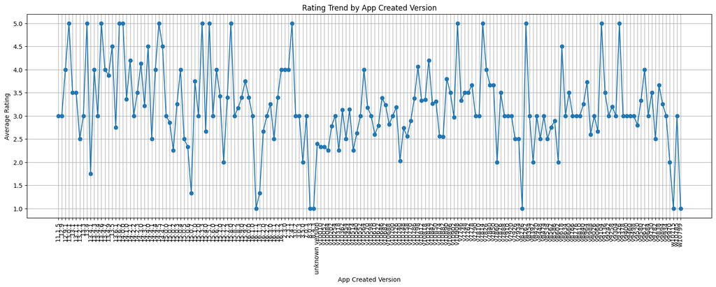

```python
# Calculates the average review score based on the app version and review time
version_ratings = doist.groupby(['app_ver'])['rating'].mean().reset_index()

# Sort data by AppCreatedVersion chronologically
version_ratings = version_ratings.sort_values(by='app_ver')

# Create line plots to see trends in changes in user ratings
plt.figure(figsize=(20, 6))
plt.plot(version_ratings['app_ver'], version_ratings['rating'], marker='o')
plt.xlabel('App Created Version')
plt.ylabel('Average Rating')
plt.title('Rating Trend by App Created Version')
plt.xticks(rotation=90)
plt.grid(True)
plt.show()
```

#### **Text Preprocessing**

Next process we want to analyze sentiment from all the reviews that users proceed in this app. This process we are conducting casefolding as part of the cleaning the text, then we're going to use package 'nltk' who provide modul sentiment.vader for easier step to labeling to find which one has positive, negative and neutral sentiment.

```python
import string
import re
import emoji

reviews = doist
```

```python
# use only reviews column for this process
reviews = reviews.drop('user', axis=1)
reviews = reviews.drop('rating', axis=1)
reviews = reviews.drop('date', axis=1)
reviews = reviews.drop('app_ver', axis=1)

reviews.head()
```

|  | reviews |
| --- | --- |
| 0 | SEIZURE RISK!!!! I have had this app for years... |
| 1 | It's been three months and the app still stops... |
| 2 | One of the main sticking points for me is how ... |
| 3 | What is the point of a "To Do" list without re... |
| 4 | To start, notifications shouldn't be a premium... |

```python
# preprocess text and clean it
def preprocess_text(sentence):
    lower_case = sentence.lower()
    result = re.sub(r"\d+", "", lower_case)
    result = result.translate(str.maketrans("", "", string.punctuation))
    result = result.strip()
    result = emoji.demojize(result) # Mengubah emoji menjadi teks
    result = re.sub(r":\S+:", "", result) # Menghapus teks emoji
    return result

# put clean text into dataframe
reviews['clean_text'] = reviews['reviews'].apply(preprocess_text)
reviews.head()
```

|  | reviews | clean_text |
| --- | --- | --- |
| 0 | SEIZURE RISK!!!! I have had this app for years... | seizure risk i have had this app for years and... |
| 1 | It's been three months and the app still stops... | its been three months and the app still stops ... |
| 2 | One of the main sticking points for me is how ... | one of the main sticking points for me is how ... |
| 3 | What is the point of a "To Do" list without re... | what is the point of a to do list without remi... |
| 4 | To start, notifications shouldn't be a premium... | to start notifications shouldnt be a premium f... |

SentimentIntensityAnalyzer adalah kelas yang digunakan untuk melakukan analisis sentimen menggunakan metode VADER (Valence Aware Dictionary and sEntiment Reasoner). Metode ini menggunakan kamus yang sudah terlatih untuk memberikan skor sentimen pada teks berdasarkan kata-kata yang terkandung di dalamnya. SentimentIntensityAnalyzer akan memberikan skor sentimen berdasarkan komponen positif, negatif, dan netral, serta skor komposit yang mencerminkan sentimen keseluruhan dari teks tersebut.

```python
from nltk.sentiment.vader import SentimentIntensityAnalyzer # import modul to execute the task

# Labeling initiation
sentiments = SentimentIntensityAnalyzer()
reviews["Positive"] = [sentiments.polarity_scores(i)["pos"] for i in reviews["clean_text"]]
reviews["Negative"] = [sentiments.polarity_scores(i)["neg"] for i in reviews["clean_text"]]
reviews["Neutral"] = [sentiments.polarity_scores(i)["neu"] for i in reviews["clean_text"]]
reviews["Compound"] = [sentiments.polarity_scores(i)["compound"] for i in reviews["clean_text"]]

reviews.head()
```

|  | reviews | clean_text | Positive | Negative | Neutral | Compound |
| --- | --- | --- | --- | --- | --- | --- |
| 0 | SEIZURE RISK!!!! I have had this app for years... | seizure risk i have had this app for years and... | 0.094 | 0.071 | 0.835 | 0.2382 |
| 1 | It's been three months and the app still stops... | its been three months and the app still stops ... | 0.125 | 0.026 | 0.849 | 0.7351 |
| 2 | One of the main sticking points for me is how ... | one of the main sticking points for me is how ... | 0.045 | 0.233 | 0.722 | -0.9685 |
| 3 | What is the point of a "To Do" list without re... | what is the point of a to do list without remi... | 0.098 | 0.017 | 0.885 | 0.7845 |
| 4 | To start, notifications shouldn't be a premium... | to start notifications shouldnt be a premium f... | 0.080 | 0.000 | 0.920 | 0.7050 |

```python
# creates a 'Sentiment' column that shows sentiment ('positive', 'negative', or 'neutral')
# based on values in the 'Compound' column.
score = reviews['Compound'].values
sentiment = []

for i in score:
  if i >= 0.05:
    sentiment.append('positive')
  elif i <= -0.05:
    sentiment.append('negative')
  else:
    sentiment.append('neutral')

reviews['Sentiment'] = sentiment
reviews.head()
```

|  | reviews | clean_text | Positive | Negative | Neutral | Compound | Sentiment |
| --- | --- | --- | --- | --- | --- | --- | --- |
| 0 | SEIZURE RISK!!!! I have had this app for years... | seizure risk i have had this app for years and... | 0.094 | 0.071 | 0.835 | 0.2382 | positive |
| 1 | It's been three months and the app still stops... | its been three months and the app still stops ... | 0.125 | 0.026 | 0.849 | 0.7351 | positive |
| 2 | One of the main sticking points for me is how ... | one of the main sticking points for me is how ... | 0.045 | 0.233 | 0.722 | -0.9685 | negative |
| 3 | What is the point of a "To Do" list without re... | what is the point of a to do list without remi... | 0.098 | 0.017 | 0.885 | 0.7845 | positive |
| 4 | To start, notifications shouldn't be a premium... | to start notifications shouldnt be a premium f... | 0.080 | 0.000 | 0.920 | 0.7050 | positive |

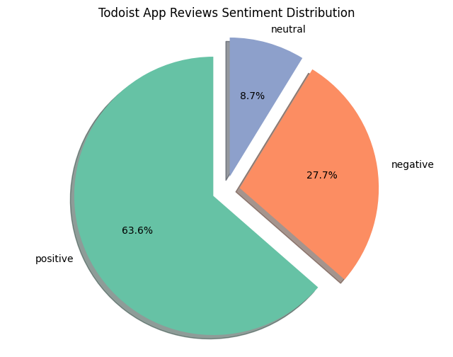

```python
# View the number of reviews by sentiment
sentiment_counts = reviews['Sentiment'].value_counts()

# Shows a visualization of the number of reviews by sentiment
plt.style.use('seaborn-pastel')

plt.figure(figsize=(8, 6))
colors = ['#66c2a5', '#fc8d62', '#8da0cb']
explode = (0.1, 0.1, 0.1)
plt.pie(sentiment_counts, labels=sentiment_counts.index, colors=colors, autopct='%1.1f%%',
        startangle=90, explode=explode, shadow=True)
plt.title('Todoist App Reviews Sentiment Distribution')
plt.axis('equal')
plt.show()
```

```python
# save dataframe into local storage
reviews.to_csv('sentiment_review_data.csv', index=False)
```

Based on the visualization and sentiment analysis results, it was found that the majority of reviews for the Todoist application on the Play Store had positive sentiments (63.6%). The number of reviews with negative sentiment (27.7%) is also significant, while the number of reviews with neutral sentiment (8.7%) is comparatively less.

In conclusion, most of the users of the Todoist application on the Play Store give positive reviews. This can be an indication that the application has good performance and meets user needs in terms of task and activity management. However, it's still worth paying attention to negative reviews to understand any issues or flaws that may need fixing to improve the overall user experience.

The next step is to do a word frequency analysis on the review content, the goal is to find out the words that appear most often. This information can assist in understanding which features users talk about the most and can provide insight into the positive or negative aspects of the app.

```python
# load some relevant libraries
import nltk
from nltk.tokenize import word_tokenize

df = reviews

df = df.drop('Positive', axis=1)
df = df.drop('Negative', axis=1)
df = df.drop('Neutral', axis=1)
df = df.drop('Compound', axis=1)
df = df.drop('Sentiment', axis=1)

df.head()
```

|  | reviews | clean_text |
| --- | --- | --- |
| 0 | SEIZURE RISK!!!! I have had this app for years... | seizure risk i have had this app for years and... |
| 1 | It's been three months and the app still stops... | its been three months and the app still stops ... |
| 2 | One of the main sticking points for me is how ... | one of the main sticking points for me is how ... |
| 3 | What is the point of a "To Do" list without re... | what is the point of a to do list without remi... |
| 4 | To start, notifications shouldn't be a premium... | to start notifications shouldnt be a premium f... |

#### **Tokenizing**

```python
# use the nltk library to split sentences into word lists.
#function takes a sentence as input and returns a list of tokens.
def tokenize_text(sentence):
    tokens = nltk.tokenize.word_tokenize(sentence)
    return tokens

df['token'] = df['clean_text'].apply(tokenize_text)
df.head()
```

|  | reviews | clean_text | token |
| --- | --- | --- | --- |
| 0 | SEIZURE RISK!!!! I have had this app for years... | seizure risk i have had this app for years and... | [seizure, risk, i, have, had, this, app, for, ... |
| 1 | It's been three months and the app still stops... | its been three months and the app still stops ... | [its, been, three, months, and, the, app, stil... |
| 2 | One of the main sticking points for me is how ... | one of the main sticking points for me is how ... | [one, of, the, main, sticking, points, for, me... |
| 3 | What is the point of a "To Do" list without re... | what is the point of a to do list without remi... | [what, is, the, point, of, a, to, do, list, wi... |
| 4 | To start, notifications shouldn't be a premium... | to start notifications shouldnt be a premium f... | [to, start, notifications, shouldnt, be, a, pr... |

```python
from nltk.corpus import stopwords
stopwords = set(stopwords.words('english'))

print(stopwords)
```

```
{"couldn't", "wouldn't", 'for', "aren't", 'doesn', 'his', 'will', 'd', 'then', 'needn', 'out', 'o', 'weren', 'having', 'has', 'below', 'by', 'very', 'himself', "shouldn't", 'those', 'shan', 'which', 'had', 'some', 'who', 'these', 'more', 'am', 'the', 'me', 'where', 'theirs', 'them', 'my', 'wouldn', …
```

```python
def stopword_text(tokens):
    cleaned_tokens = []
    for token in tokens:
        if token not in stopwords:
            cleaned_tokens.append(token)
    return cleaned_tokens

df['stop'] = df['token'].apply(stopword_text)
df.head()
```

|  | reviews | clean_text | token | stop |
| --- | --- | --- | --- | --- |
| 0 | SEIZURE RISK!!!! I have had this app for years... | seizure risk i have had this app for years and... | [seizure, risk, i, have, had, this, app, for, ... | [seizure, risk, app, years, recommended, many,... |
| 1 | It's been three months and the app still stops... | its been three months and the app still stops ... | [its, been, three, months, and, the, app, stil... | [three, months, app, still, stops, syncing, pe... |
| 2 | One of the main sticking points for me is how ... | one of the main sticking points for me is how ... | [one, of, the, main, sticking, points, for, me... | [one, main, sticking, points, well, app, recur... |
| 3 | What is the point of a "To Do" list without re... | what is the point of a to do list without remi... | [what, is, the, point, of, a, to, do, list, wi... | [point, list, without, reminders, nope, dont, ... |
| 4 | To start, notifications shouldn't be a premium... | to start notifications shouldnt be a premium f... | [to, start, notifications, shouldnt, be, a, pr... | [start, notifications, shouldnt, premium, feat... |

#### **Stemming**

```python
from nltk.stem import PorterStemmer
stemmer = PorterStemmer()
```

```python
def stemming_text(tokens):
    hasil = [stemmer.stem(token) for token in tokens]
    return hasil

df['stemmed'] = df['stop'].apply(stemming_text)
df.head()
```

|  | reviews | clean_text | token | stop | stemmed |
| --- | --- | --- | --- | --- | --- |
| 0 | SEIZURE RISK!!!! I have had this app for years... | seizure risk i have had this app for years and... | [seizure, risk, i, have, had, this, app, for, ... | [seizure, risk, app, years, recommended, many,... | [seizur, risk, app, year, recommend, mani, peo... |
| 1 | It's been three months and the app still stops... | its been three months and the app still stops ... | [its, been, three, months, and, the, app, stil... | [three, months, app, still, stops, syncing, pe... | [three, month, app, still, stop, sync, period,... |
| 2 | One of the main sticking points for me is how ... | one of the main sticking points for me is how ... | [one, of, the, main, sticking, points, for, me... | [one, main, sticking, points, well, app, recur... | [one, main, stick, point, well, app, recur, ta... |
| 3 | What is the point of a "To Do" list without re... | what is the point of a to do list without remi... | [what, is, the, point, of, a, to, do, list, wi... | [point, list, without, reminders, nope, dont, ... | [point, list, without, remind, nope, dont, get... |
| 4 | To start, notifications shouldn't be a premium... | to start notifications shouldnt be a premium f... | [to, start, notifications, shouldnt, be, a, pr... | [start, notifications, shouldnt, premium, feat... | [start, notif, shouldnt, premium, featur, main... |

The following is to visualize some of the keywords that often appear for some of the keywords that have been defined

```python
from nltk.probability import FreqDist

all_tokens = [token for sublist in df['stop'] for token in sublist]
freq_dist = FreqDist(all_tokens)
print(freq_dist.most_common())
```

```
[('app', 1125), ('tasks', 492), ('task', 393), ('one', 269), ('list', 256), ('use', 249), ('like', 244), ('good', 218), ('time', 217), ('todoist', 198), ('would', 192), ('great', 190), ('widget', 180), ('reminders', 170), ('get', 170), ('version', 167), ('im', 161), ('really', 159), ('add', 157), ('…
```

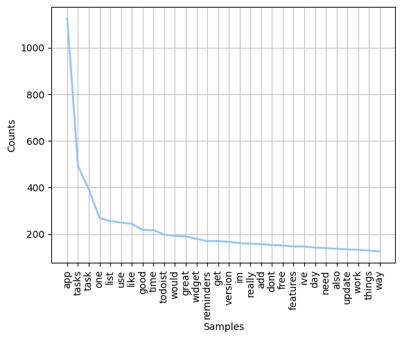

```python
freq_dist.plot(30, cumulative=False)
plt.show()
```

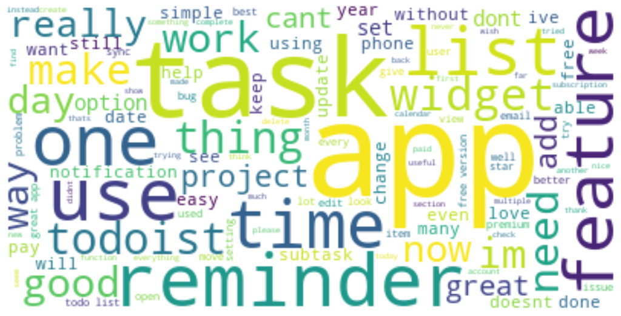

```python
# plot the stopwords into visualization, this time we are going to use wordcloud to do it
from wordcloud import WordCloud
from wordcloud import STOPWORDS

text = " ".join(i for i in df.clean_text)
stopwords = set(STOPWORDS)
wordcloud = WordCloud(stopwords=stopwords, background_color="white").generate(text)
plt.figure(figsize=(15,10))
plt.imshow(wordcloud, interpolation='bilinear')
plt.axis("off")
plt.show()
```

```python
# save dataframe into local storage
df.to_csv('freq_word_data.csv', index=False)
```

#### **Conclusion**

From the process and the findings obtained above, the following conclusions can be drawn:

Overall, these findings indicate that Todoist is a popular and effective application in helping users organize and manage their tasks. Features such as time management, reminders, and widgets provide a satisfying experience for users in using this application.